# R 語言的五十道練習

> 函數型程式設計

[數據交點](https://www.datainpoint.com/) | 郭耀仁 yaojenkuo@datainpoint.com

## 常用的 R 內建函數

## 內建數值函數

## `abs()`

取絕對值。

```r
print(abs(-5566))
print(abs(5566))
```

```
[1] 5566
[1] 5566
```

## `sqrt()`

取平方根。

```r
print(sqrt(2))
print(sqrt(3))
```

```
[1] 1.414214
[1] 1.732051
```

## `ceiling()`

無條件進位。

```r
print(ceiling(sqrt(2)))
print(ceiling(sqrt(3)))
```

```
[1] 2
[1] 2
```

## `floor()`

無條件捨去。

```r
print(floor(sqrt(2)))
print(floor(sqrt(3)))
```

```
[1] 1
[1] 1
```

## `round()`

四捨五入。

```r
print(round(sqrt(2)))
print(round(sqrt(3)))
```

```
[1] 1
[1] 2
```

## `exp()`

\begin{equation} exp(x) = e^x \\ \text{where } e = 2.71828... \end{equation}

```r
print(exp(1))
print(exp(2))
```

```
[1] 2.718282
[1] 7.389056
```

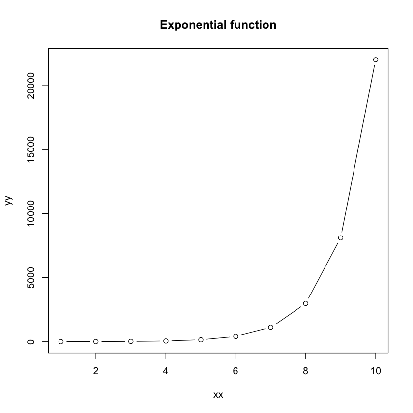

```r
xx <- 1:10
yy <- exp(xx)
plot(xx, yy, type = "b")
title("Exponential function")
```

## `log()`

以 $e$ 為底的對數函數。

```r
e = exp(1)
ee = exp(2)
print(log(e))
print(log(ee))
```

```
[1] 1
[1] 2
```

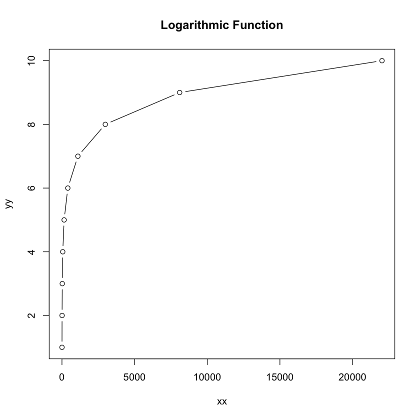

```r
xx <- exp(1:10)
yy <- log(xx)
plot(xx, yy, type = "b")
title("Logarithmic Function")
```

## `log10()`

以 10 為底的對數函數。

```r
print(log10(10))
print(log10(10**2))
```

```
[1] 1
[1] 2
```

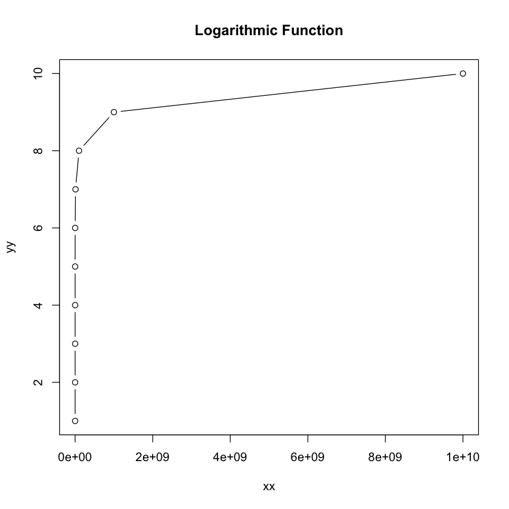

```r
xx <- 10^(1:10)
yy <- log10(xx)
plot(xx, yy, type = "b")
title("Logarithmic Function")
```

## 內建描述性統計函數

## `mean()`

平均數。

```r
print(mean(1:10))
```

```
[1] 5.5
```

## `sd()`

標準差。

```r
print(sd(1:10))
```

```
[1] 3.02765
```

## `median()`

中位數。

```r
print(median(1:9))
print(median(1:10))
```

```
[1] 5
[1] 5.5
```

## `range()`

最大值與最小值。

```r
print(range(11:100))
```

```
[1]  11 100
```

## `sum()`

加總。

```r
print(sum(1:100))
```

```
[1] 5050
```

## `max()`

最大值。

```r
print(max(11:100))
```

```
[1] 100
```

## `min()`

最小值。

```r
print(min(11:100))
```

```
[1] 11
```

## 內建文字處理函數

## `unique()`

取獨一值。

```r
cities <- c("New York", "Boston", "Tokyo", "Kyoto", "Taipei")
countries <- c("United States", "United States", "Japan", "Japan", "Taiwan")
print(unique(cities))
print(unique(countries))
```

```
[1] "New York" "Boston"   "Tokyo"    "Kyoto"    "Taipei"
[1] "United States" "Japan"         "Taiwan"
```

## `toupper()`

轉換為大寫。

```r
print(toupper("Luke, use the Force!"))
```

```
[1] "LUKE, USE THE FORCE!"
```

## `tolower()`

轉換為小寫。

```r
print(tolower("Luke, use the Force!"))
```

```
[1] "luke, use the force!"
```

## `nchar()`

計算文字的字元個數，number of characters。

```r
print(length("Luke, use the Force"))
print(nchar("Luke, use the Force"))
```

```
[1] 1
[1] 19
```

## `substr()`

擷取部分文字片段。

```r
luke <- "Luke Skywalker"
print(substr(luke, start = 1, stop = 4))
print(substr(luke, start = 6, stop = nchar(luke)))
```

```
[1] "Luke"
[1] "Skywalker"
```

## `grep()`

回傳指定特徵有出現的索引值。

```r
avengers <- c("The Avengers", "Avengers: Age of Ultron", "Avengers: Infinity War", "Avengers: Endgame")
print(grep(pattern = "Avengers", avengers))
print(grep(pattern = "Endgame", avengers))
```

```
[1] 1 2 3 4
[1] 4
```

## `sub()`

取代指定特徵。

```r
skywalker <- "Anakin Skywalker"
print(skywalker)
print(sub(pattern = "Anakin", replacement = "Luke", skywalker))
```

```
[1] "Anakin Skywalker"
[1] "Luke Skywalker"
```

## `strsplit()`

依據指定特徵分割文字。

```r
avengers <- c("The Avengers", "Avengers: Age of Ultron", "Avengers: Infinity War", "Avengers: Endgame")
print(strsplit(avengers, split = " "))
```

```
[[1]]
[1] "The"      "Avengers"

[[2]]
[1] "Avengers:" "Age"       "of"        "Ultron"

[[3]]
[1] "Avengers:" "Infinity"  "War"

[[4]]
[1] "Avengers:" "Endgame"
```

## `paste()` 與 `paste0()`

連接文字。

```r
print(paste("Avengers:", "Endgame"))
print(paste0("Avengers:", "Endgame"))
```

```
[1] "Avengers: Endgame"
[1] "Avengers:Endgame"
```

## `trimws()`

消除前（leading）或後（trailing）的空白。

```r
luke <- "     Luke, use the Force!     "
print(trimws(luke))
print(trimws(luke, which = "left"))
print(trimws(luke, which = "right"))
```

```
[1] "Luke, use the Force!"
[1] "Luke, use the Force!     "
[1] "     Luke, use the Force!"
```

## 自訂函數的輸入與輸出個數

## 單一輸入

將攝氏溫度轉換為華氏溫度的函數 `celsius_to_fahrenheit()`

\begin{equation} Fahrenheit_{(°F)} = Celsius_{(°C)} \times \frac{9}{5} + 32 \end{equation}

```r
celsius_to_fahrenheit <- function(x) {
    return(x*9/5 + 32)
}
print(celsius_to_fahrenheit(100))
```

```
[1] 212
```

## 兩個以上輸入

```r
get_bmi <- function(height, weight) {
    return(weight / (height*0.01)**2)
}
print(get_bmi(216, 147))
```

```
[1] 31.5072
```

## 參數有預設值

```r
temperature_convert <- function(x, to_fahrenheit = TRUE) {
    if (to_fahrenheit) {
        return(x*9/5 + 32)
    } else {
        return((x - 32)*5/9)
    }
}
print(temperature_convert(100))
print(temperature_convert(212, to_fahrenheit = FALSE))
```

```
[1] 212
[1] 100
```

## 多個輸出

```r
get_bmi_and_label <- function(height, weight) {
    bmi <- weight / (height/100)**2
    if (bmi > 30) {
        label <- "Obese"
    } else if (bmi < 18.5) {
        label <- "Underweight"
    } else if (bmi > 25) {
        label <- "Overweight"
    } else {
        label <- "Normal weight"
    }
    bmi_and_label <- list(
        bmi = bmi,
        bmi_label = label
    )
    return(bmi_and_label)
}
```

```r
print(get_bmi_and_label(216, 147)) # Shaquille O'Neal
print(get_bmi_and_label(203, 113)) # LeBron James
```

```
$bmi
[1] 31.5072

$bmi_label
[1] "Obese"

$bmi
[1] 27.42119

$bmi_label
[1] "Overweight"
```

## 向量化函數

## 什麼是向量化函數？

利用函數型函數（Functional functions）將指定函數**向量化**至某個資料結構的技巧。

```r
# 將一個 list 中的每個數字都平方
my_list <- list(
    11,
    12,
    13,
    14,
    15
)
print(my_list)
```

```
[[1]]
[1] 11

[[2]]
[1] 12

[[3]]
[1] 13

[[4]]
[1] 14

[[5]]
[1] 15
```

## 老實說，我們會有個衝動這樣寫

```
my_list**2
```

## 注意這是一個 `list` 而不是向量

```r
for (i in my_list) {
    print(i**2)
}
```

```
[1] 121
[1] 144
[1] 169
[1] 196
[1] 225
```

## 使用 `lapply()` 將 `get_squared()` 函數向量化至 `my_list` 之上

```r
get_squared <- function(x) {
    return(x**2)
}

print(lapply(my_list, FUN = get_squared))
```

```
[[1]]
[1] 121

[[2]]
[1] 144

[[3]]
[1] 169

[[4]]
[1] 196

[[5]]
[1] 225
```

## 搭配匿名函數（Anonymous functions）將平方運算向量化至 `my_list` 之上

```
# Named function
named_function <- function(INPUTS) {
    # sequence of statements
    # sequence of statements
    return(OUTPUTS)
}
# Anonymous function
function(INPUTS) return(OUTPUTS)
```

```r
print(lapply(my_list, FUN = function(x) return(x**2)))
```

```
[[1]]
[1] 121

[[2]]
[1] 144

[[3]]
[1] 169

[[4]]
[1] 196

[[5]]
[1] 225
```

## R 常用的函數型函數（Functional functions）

- `lapply()`
- `sapply()`
- `apply()`
- `mapply()`

## `sapply()`

- Simplified apply
- 回傳向量而非 `list`

```r
print(sapply(my_list, FUN = function(x) return(x**2)))
```

```
[1] 121 144 169 196 225
```

## `apply()`

將函數向量化至二維的資料結構（`matrix` 與 `data.frame`）

```r
my_matrix <- matrix(1:12, nrow = 2)
print(my_matrix)
print(apply(my_matrix, MARGIN = 1, FUN = sum))
print(apply(my_matrix, MARGIN = 2, FUN = sum))
```

```
     [,1] [,2] [,3] [,4] [,5] [,6]
[1,]    1    3    5    7    9   11
[2,]    2    4    6    8   10   12
[1] 36 42
[1]  3  7 11 15 19 23
```

## `mapply()`

將具有多個輸入的函數向量化

```r
weights <- list(91, 82, 113, 147)
heights <- list(231, 191, 203, 216)
bmis <- mapply(FUN = function(h, w) return(w/(h*0.01)**2), heights, weights)
print(bmis)
```

```
[1] 17.05365 22.47745 27.42119 31.50720
```